# AfriMarket — Analyse Stratégique des Données

**Contexte :** AfriMarket est une entreprise e-commerce panafricaine (Électronique, Mode, Beauté, Maison) opérant dans plusieurs grandes villes d'Afrique francophone. La direction constate des variations de CA, un taux de retour préoccupant, des dépenses marketing élevées et des écarts de performance selon les villes.

**Mission :** produire une analyse stratégique complète (6 mois d'activité) permettant à la direction de prendre des décisions business.

**Sommaire**

1. Audit & Compréhension des données
2. Data Cleaning
3. Feature Engineering
4. Analyses (performance globale, catégorie, géographie, marketing, clients)
5. Synthèse des questions stratégiques

```python
import pandas as pd
import numpy as np
import matplotlib.pyplot as plt
import seaborn as sns
import plotly.express as px

sns.set_theme(style="whitegrid")
plt.rcParams["figure.figsize"] = (10, 5)
pd.set_option("display.float_format", lambda v: f"{v:,.2f}")

RAW_PATH = "../data/afrimarket_dataset_senior.csv"
CLEAN_PATH = "../data/df_clean.csv"
```

## 1. Audit & Compréhension des données

```python
df_raw = pd.read_csv(RAW_PATH)
print(f"Dimensions : {df_raw.shape[0]} lignes x {df_raw.shape[1]} colonnes")
df_raw.head()
```

```
Dimensions : 10100 lignes x 14 colonnes
```

|  | id_commande | date_commande | id_client | ville | categorie | nom_produit | prix_unitaire | quantite | remise | cout_livraison | methode_paiement | canal_marketing | cout_marketing | statut_commande |
| --- | --- | --- | --- | --- | --- | --- | --- | --- | --- | --- | --- | --- | --- | --- |
| 0 | CMD100000 | 2025-12-11 | C0379 | Brazzaville | Mode | Produit_Mode_9 | 49.72 | 3 | 0.07 | 2.45 | Mobile Money | Email | 1.00 | Livrée |
| 1 | CMD100001 | 2025-07-27 | C1827 | Libreville | Beauté | Produit_Beauté_3 | 37.18 | 2 | 0.10 | 6.89 | Paiement à la livraison | Instagram Ads | 8.04 | Livrée |
| 2 | CMD100002 | 2025-07-08 | C0119 | Abidjan | electronique | Produit_Électronique_36 | 315.60 | 0 | 0.04 | 5.60 | Carte | Google Ads | 7.30 | Livrée |
| 3 | CMD100003 | 2025-08-20 | C1436 | Libreville | electronique | Produit_Électronique_29 | 143.25 | 0 | 0.03 | 5.96 | Mobile Money | Google Ads | 5.20 | Livrée |
| 4 | CMD100004 | 2025-11-28 | C0003 | Libreville | Électronique | Produit_Électronique_45 | 498.71 | 2 | 0.02 | 5.16 | Mobile Money | Email | 0.55 | Livrée |

```python
df_raw.info()
```

```
<class 'pandas.DataFrame'>
RangeIndex: 10100 entries, 0 to 10099
Data columns (total 14 columns):
 #   Column            Non-Null Count  Dtype
---  ------            --------------  -----
 0   id_commande       10100 non-null  str
 1   date_commande     10100 non-null  str
 2   id_client         10100 non-null  str
 3   ville             10100 non-null  str
 4   categorie         10100 non-null  str
 5   nom_produit       10100 non-null  str
 6   prix_unitaire     10100 non-null  float64
 7   quantite          10100 non-null  int64
 8   remise            10100 non-null  float64
 9   cout_livraison    10100 non-null  float64
 10  methode_paiement  10100 non-null  str
 11  canal_marketing   10100 non-null  str
 12  cout_marketing    10100 non-null  float64
 13  statut_commande   10100 non-null  str
dtypes: float64(4), int64(1), str(9)
memory usage: 1.9 MB
```

```python
# Valeurs manquantes
df_raw.isna().sum().to_frame("valeurs_manquantes")
```

|  | valeurs_manquantes |
| --- | --- |
| id_commande | 0 |
| date_commande | 0 |
| id_client | 0 |
| ville | 0 |
| categorie | 0 |
| nom_produit | 0 |
| prix_unitaire | 0 |
| quantite | 0 |
| remise | 0 |
| cout_livraison | 0 |
| methode_paiement | 0 |
| canal_marketing | 0 |
| cout_marketing | 0 |
| statut_commande | 0 |

```python
# Doublons stricts
n_dup = df_raw.duplicated().sum()
print(f"Doublons stricts détectés : {n_dup}")
```

```
Doublons stricts détectés : 100
```

```python
# Incohérences catégorielles : villes, catégories, statuts
print("Villes :", sorted(df_raw['ville'].unique()))
print()
print("Catégories :", sorted(df_raw['categorie'].unique()))
print()
print("Statuts :", sorted(df_raw['statut_commande'].unique()))
```

```
Villes : ['Abidjan', 'Brazzaville', 'Cotonou', 'Dakar', 'Douala', 'Kinshasa', 'Kinshassa', 'Libreville', 'Lomé']

Catégories : ['Beauté', 'Maison', 'Mode', 'electronique', 'Électronique']

Statuts : ['Annulée', 'Livrée', 'retournée']
```

```python
# Colonnes numériques lues comme texte (indice de zéros en tête, ex: "08.5")
print(df_raw['cout_marketing'].dtype, df_raw['cout_livraison'].dtype)
df_raw[['cout_marketing', 'cout_livraison']].head()
```

```
float64 float64
```

|  | cout_marketing | cout_livraison |
| --- | --- | --- |
| 0 | 1.00 | 2.45 |
| 1 | 8.04 | 6.89 |
| 2 | 7.30 | 5.60 |
| 3 | 5.20 | 5.96 |
| 4 | 0.55 | 5.16 |

```python
# Valeurs aberrantes
n_remise_neg = (df_raw['remise'] < 0).sum()
n_prix_negatif_nul = (df_raw['prix_unitaire'] <= 0).sum()
n_qty_zero = (df_raw['quantite'] == 0).sum()

print(f"Remises négatives      : {n_remise_neg} (min = {df_raw['remise'].min()})")
print(f"Prix unitaires <= 0    : {n_prix_negatif_nul} (min = {df_raw['prix_unitaire'].min()})")
print(f"Quantités nulles       : {n_qty_zero}")
```

```
Remises négatives      : 614 (min = -0.1)
Prix unitaires <= 0    : 632 (min = -50.0)
Quantités nulles       : 608
```

### Résumé de l'audit

[output not shown]

**Conclusion de l'audit :** le dataset est exploitable mais nécessite un nettoyage structuré avant toute analyse fiable. Aucun retraitement n'est fait sur les axes d'analyse (villes, catégories, canaux) sans le nettoyage préalable.

## 2. Data Cleaning

Chaque correction ci-dessous répond à un problème identifié dans l'audit ci-dessus.

```python
df = df_raw.copy()
n_raw = len(df)

# 2.1 Doublons stricts
n_dup = df.duplicated().sum()
df = df.drop_duplicates()
```

```python
# 2.2 Dates : standardisation au format datetime
df["date_commande"] = pd.to_datetime(df["date_commande"], format="%Y-%m-%d")
```

```python
# 2.3 Villes : correction orthographe
df["ville"] = df["ville"].replace({"Kinshassa": "Kinshasa"})
```

```python
# 2.4 Catégories : uniformisation casse / accents
df["categorie"] = df["categorie"].replace({"electronique": "Électronique"})
```

```python
# 2.5 Statuts : casse normalisée (accents conservés)
df["statut_commande"] = df["statut_commande"].str.strip().str.capitalize()
```

```python
# 2.6 Remises négatives : erreur de saisie de signe -> valeur absolue, plafonnée à 50%
df["remise"] = df["remise"].abs().clip(upper=0.5)
```

```python
# 2.7 Prix aberrants (<= 0) : traités comme manquants puis imputés par la médiane du produit,
# avec repli sur la médiane de la catégorie si le produit n'a aucune valeur valide
df.loc[df["prix_unitaire"] <= 0, "prix_unitaire"] = np.nan
df["prix_unitaire"] = df.groupby("nom_produit")["prix_unitaire"].transform(lambda s: s.fillna(s.median()))
df["prix_unitaire"] = df.groupby("categorie")["prix_unitaire"].transform(lambda s: s.fillna(s.median()))
```

```python
# 2.8 Quantités nulles : une commande à 0 article n'est pas une vente réelle -> suppression
n_qty_zero = (df["quantite"] == 0).sum()
df = df[df["quantite"] > 0]
```

```python
# 2.9 Typage numérique des coûts
df["cout_marketing"] = df["cout_marketing"].astype(float)
df["cout_livraison"] = df["cout_livraison"].astype(float)

df = df.reset_index(drop=True)
```

```python
print(f"Lignes brutes         : {n_raw}")
print(f"Doublons supprimés     : {n_dup}")
print(f"Quantités nulles suppr.: {n_qty_zero}")
print(f"Lignes après nettoyage : {len(df)}")
df.dtypes
```

```
Lignes brutes         : 10100
Doublons supprimés     : 100
Quantités nulles suppr.: 600
Lignes après nettoyage : 9400
```

```
id_commande                    str
date_commande       datetime64[us]
id_client                      str
ville                          str
categorie                      str
nom_produit                    str
prix_unitaire              float64
quantite                     int64
remise                     float64
cout_livraison             float64
methode_paiement               str
canal_marketing                str
cout_marketing             float64
statut_commande                str
dtype: object
```

```python
df.to_csv(CLEAN_PATH, index=False)
print(f"df_clean sauvegardé -> {CLEAN_PATH}")
```

```
df_clean sauvegardé -> ../data/df_clean.csv
```

## 3. Feature Engineering

**Hypothèse posée (documentée car aucun coût produit n'est fourni) :** taux de marge brute par catégorie, basés sur des repères sectoriels usuels de l'e-commerce panafricain :

| Catégorie | Taux de marge brute supposé |
| --- | --- |
| Électronique | 15 % (marge faible, produits à forte concurrence prix) |
| Mode | 45 % |
| Beauté | 55 % |
| Maison | 35 % |

**Convention métier :** une commande **Annulée** ne génère aucune vente réelle → son chiffre d'affaires est ramené à 0. Une commande **Retournée** a bien généré une vente (elle est comptée dans le CA et le profit) mais est signalée via `indicateur_retour` : c'est un signal de risque qualité, pas une perte de revenu immédiate.

```python
TAUX_MARGE = {
    "Électronique": 0.15,
    "Mode": 0.45,
    "Beauté": 0.55,
    "Maison": 0.35,
}

# Chiffre d'affaires (0 pour les commandes annulées)
df["chiffre_affaires"] = np.where(
    df["statut_commande"] == "Annulée",
    0.0,
    df["prix_unitaire"] * df["quantite"] * (1 - df["remise"]),
)

# Marge brute estimée
df["marge_brute"] = df["chiffre_affaires"] * df["categorie"].map(TAUX_MARGE)

# Profit net estimé (marge brute - coûts logistiques et marketing de la commande)
df["profit_net"] = df["marge_brute"] - df["cout_livraison"] - df["cout_marketing"]

# Mois (période Y-M, pour les analyses d'évolution mensuelle)
df["mois"] = df["date_commande"].dt.to_period("M").astype(str)

# Indicateurs de statut
df["indicateur_retour"] = (df["statut_commande"] == "Retournée").astype(int)
df["indicateur_annulation"] = (df["statut_commande"] == "Annulée").astype(int)

# Nombre de commandes par client (sur les 6 mois observés)
df["nombre_commandes_par_client"] = df.groupby("id_client")["id_commande"].transform("count")

# Valeur vie client simplifiée = somme du CA généré par le client sur la période observée
df["valeur_vie_client"] = df.groupby("id_client")["chiffre_affaires"].transform("sum")

df[["chiffre_affaires", "marge_brute", "profit_net", "mois", "indicateur_retour",
    "nombre_commandes_par_client", "valeur_vie_client"]].head()
```

|  | chiffre_affaires | marge_brute | profit_net | mois | indicateur_retour | nombre_commandes_par_client | valeur_vie_client |
| --- | --- | --- | --- | --- | --- | --- | --- |
| 0 | 138.72 | 62.42 | 58.97 | 2025-12 | 0 | 25 | 9,105.69 |
| 1 | 66.92 | 36.81 | 21.88 | 2025-07 | 0 | 4 | 562.86 |
| 2 | 977.47 | 146.62 | 140.91 | 2025-11 | 0 | 26 | 9,516.10 |
| 3 | 192.16 | 67.26 | 53.18 | 2025-10 | 0 | 17 | 4,690.20 |
| 4 | 62.21 | 27.99 | 15.17 | 2025-07 | 0 | 16 | 3,491.20 |

```python
FEATURES_PATH = "../data/df_features.csv"
df.to_csv(FEATURES_PATH, index=False)
print(f"df_features (dataset enrichi) sauvegardé -> {FEATURES_PATH}")
```

```
df_features (dataset enrichi) sauvegardé -> ../data/df_features.csv
```

## 4. Analyses

### 4.1 Performance globale

```python
commandes_valides = df[df["statut_commande"] != "Annulée"]

ca_total = df["chiffre_affaires"].sum()
profit_net_total = df["profit_net"].sum()
panier_moyen = commandes_valides["chiffre_affaires"].sum() / len(commandes_valides)
taux_annulation = df["indicateur_annulation"].mean()
taux_retour = df["indicateur_retour"].mean()

print(f"CA total               : {ca_total:,.0f}")
print(f"Profit net estimé       : {profit_net_total:,.0f}")
print(f"Panier moyen            : {panier_moyen:,.2f}")
print(f"Taux d'annulation       : {taux_annulation:.1%}")
print(f"Taux de retour          : {taux_retour:.1%}")
```

```
CA total               : 2,500,434
Profit net estimé       : 410,380
Panier moyen            : 271.29
Taux d'annulation       : 1.9%
Taux de retour          : 8.1%
```

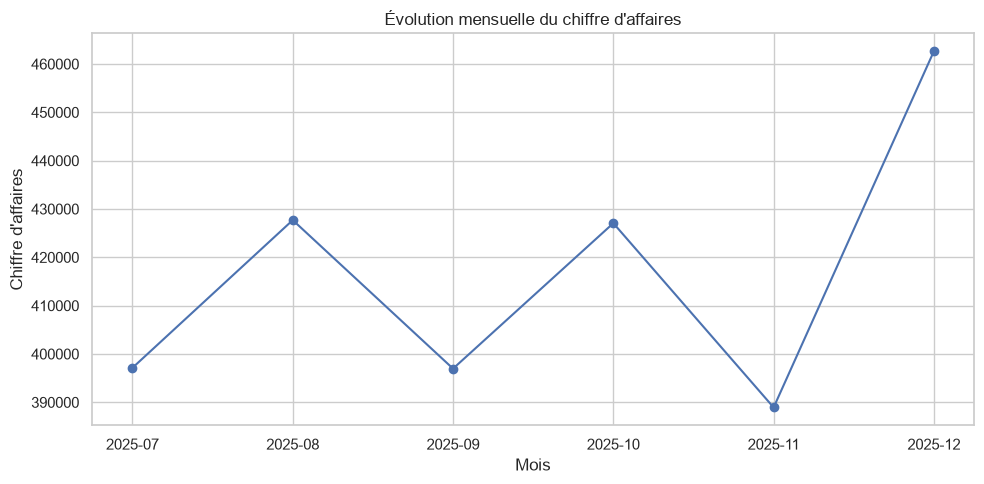

```python
ca_mensuel = df.groupby("mois")["chiffre_affaires"].sum().sort_index()

fig, ax = plt.subplots()
ca_mensuel.plot(marker="o", ax=ax)
ax.set_title("Évolution mensuelle du chiffre d'affaires")
ax.set_ylabel("Chiffre d'affaires")
ax.set_xlabel("Mois")
plt.tight_layout()
plt.show()
```

### 4.2 Analyse par catégorie

```python
par_categorie = df.groupby("categorie").agg(
    ca=("chiffre_affaires", "sum"),
    marge=("marge_brute", "sum"),
    taux_retour=("indicateur_retour", "mean"),
).sort_values("ca", ascending=False)
par_categorie
```

| categorie | ca | marge | taux_retour |
| --- | --- | --- | --- |
| Électronique | 1,863,469.17 | 279,520.38 | 0.14 |
| Maison | 374,629.86 | 131,120.45 | 0.05 |
| Mode | 185,938.72 | 83,672.43 | 0.07 |
| Beauté | 76,396.30 | 42,017.97 | 0.03 |

[output not shown]

[output not shown]

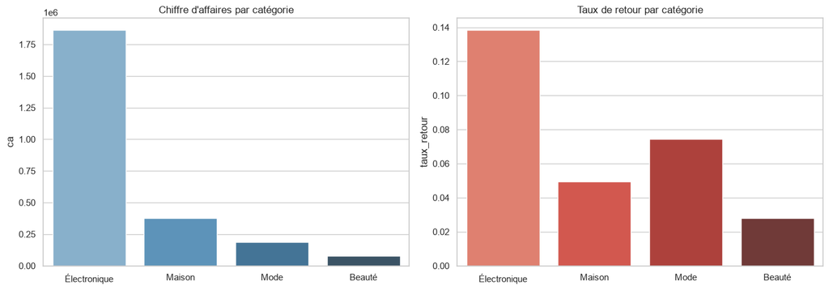

```python
fig, axes = plt.subplots(1, 2, figsize=(14, 5))
sns.barplot(data=par_categorie.reset_index(), x="categorie", y="ca", ax=axes[0], palette="Blues_d")
axes[0].set_title("Chiffre d'affaires par catégorie")
axes[0].set_xlabel("")

sns.barplot(data=par_categorie.reset_index(), x="categorie", y="taux_retour", ax=axes[1], palette="Reds_d")
axes[1].set_title("Taux de retour par catégorie")
axes[1].set_xlabel("")
plt.tight_layout()
plt.show()
```

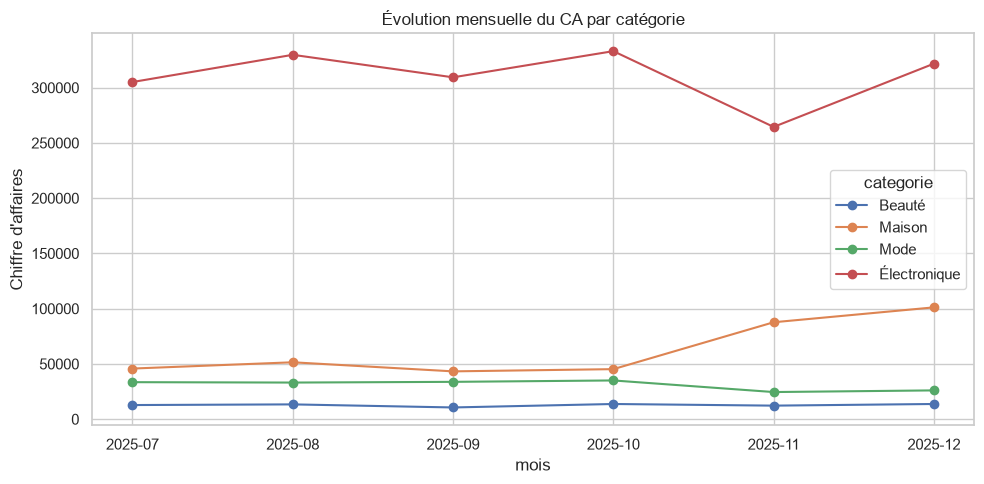

```python
evolution_categorie = df.pivot_table(index="mois", columns="categorie", values="chiffre_affaires", aggfunc="sum").sort_index()

fig, ax = plt.subplots()
evolution_categorie.plot(marker="o", ax=ax)
ax.set_title("Évolution mensuelle du CA par catégorie")
ax.set_ylabel("Chiffre d'affaires")
plt.tight_layout()
plt.show()
```

**Question stratégique — quelle catégorie prioriser ?**

*(à conclure après lecture des résultats ci-dessus dans le résumé exécutif : croiser le CA, la marge et le taux de retour — une catégorie à fort CA mais fort taux de retour et faible marge n'est pas nécessairement à prioriser.)*

### 4.3 Analyse géographique

```python
par_ville = df.groupby("ville").agg(
    ca=("chiffre_affaires", "sum"),
    profit=("profit_net", "sum"),
    taux_annulation=("indicateur_annulation", "mean"),
).sort_values("ca", ascending=False)
par_ville
```

| ville | ca | profit | taux_annulation |
| --- | --- | --- | --- |
| Kinshasa | 753,603.34 | 124,173.19 | 0.00 |
| Abidjan | 498,891.35 | 81,420.13 | 0.00 |
| Dakar | 347,077.76 | 58,166.21 | 0.00 |
| Douala | 327,934.46 | 51,855.18 | 0.13 |
| Lomé | 183,823.47 | 30,537.38 | 0.00 |
| Cotonou | 159,013.22 | 26,649.82 | 0.00 |
| Libreville | 123,648.39 | 20,347.63 | 0.00 |
| Brazzaville | 106,442.07 | 17,229.99 | 0.00 |

[output not shown]

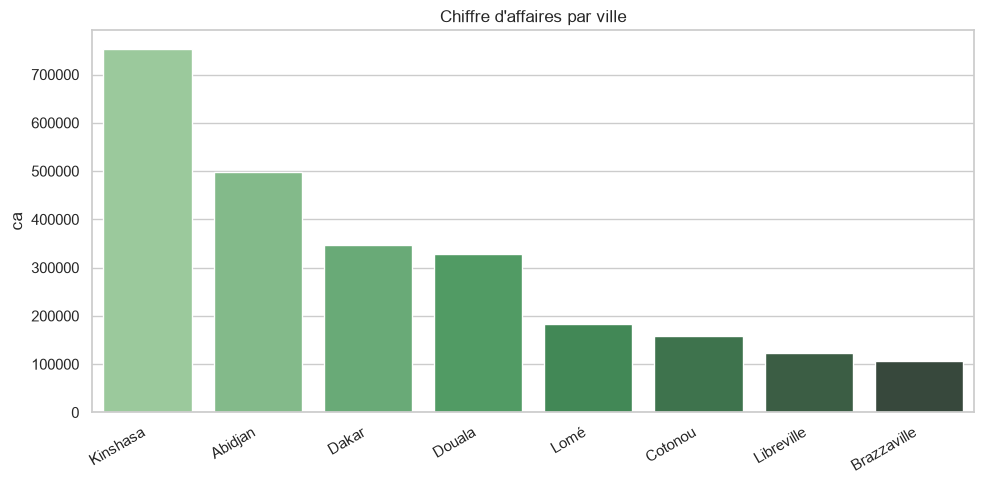

```python
fig, ax = plt.subplots()
sns.barplot(data=par_ville.reset_index(), x="ville", y="ca", palette="Greens_d", ax=ax)
ax.set_title("Chiffre d'affaires par ville")
ax.set_xlabel("")
plt.xticks(rotation=30, ha="right")
plt.tight_layout()
plt.show()
```

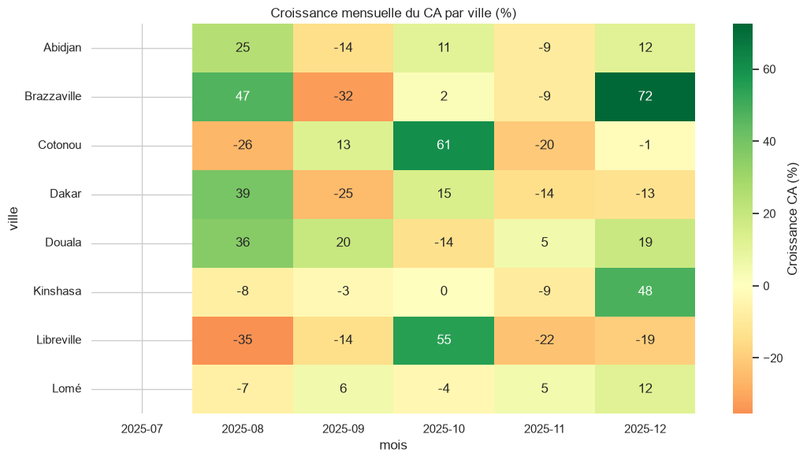

```python
croissance_ville = df.pivot_table(index="mois", columns="ville", values="chiffre_affaires", aggfunc="sum").sort_index()
croissance_pct = croissance_ville.pct_change() * 100

fig, ax = plt.subplots(figsize=(11, 6))
sns.heatmap(croissance_pct.T, annot=True, fmt=".0f", cmap="RdYlGn", center=0, ax=ax,
            cbar_kws={"label": "Croissance CA (%)"})
ax.set_title("Croissance mensuelle du CA par ville (%)")
plt.tight_layout()
plt.show()
```

**Question stratégique — où investir davantage ?**

*(à conclure dans le résumé exécutif en croisant CA, profit et dynamique de croissance par ville — une ville à fort CA mais en décroissance est un signal différent d'une ville plus petite mais en forte croissance.)*

### 4.4 Analyse marketing

```python
par_canal = df.groupby("canal_marketing").agg(
    ca=("chiffre_affaires", "sum"),
    cout_marketing_total=("cout_marketing", "sum"),
)
par_canal["roi"] = (par_canal["ca"] - par_canal["cout_marketing_total"]) / par_canal["cout_marketing_total"]

retention_canal = df.groupby("canal_marketing")["nombre_commandes_par_client"].apply(
    lambda s: (s > 1).mean()
)
par_canal["taux_retention"] = retention_canal
par_canal.sort_values("roi", ascending=False)
```

| canal_marketing | ca | cout_marketing_total | roi | taux_retention |
| --- | --- | --- | --- | --- |
| Email | 529,200.59 | 2,349.15 | 224.27 | 0.95 |
| Google Ads | 663,808.57 | 13,158.93 | 49.45 | 0.96 |
| Instagram Ads | 947,691.93 | 37,637.07 | 24.18 | 0.95 |
| Influenceur | 359,732.98 | 16,359.59 | 20.99 | 0.95 |

```python
from IPython.display import HTML

fig = px.bar(
    par_canal.reset_index().sort_values("roi", ascending=False),
    x="canal_marketing", y="roi", color="roi", color_continuous_scale="RdYlGn",
    title="ROI marketing par canal", labels={"canal_marketing": "Canal", "roi": "ROI"},
)
fig.update_layout(showlegend=False)
HTML(fig.to_html(include_plotlyjs="cdn", full_html=False))
```

[interactive chart not shown]

**Question stratégique — quel canal renforcer / réduire ?**

*(à conclure dans le résumé exécutif : un canal à fort ROI mais faible rétention finance de l'acquisition sans fidélisation ; un canal à ROI négatif consomme du budget sans retour.)*

### 4.5 Analyse clients

```python
n_clients = df["id_client"].nunique()
clients_recurrents = df.drop_duplicates("id_client")
pct_recurrents = (clients_recurrents["nombre_commandes_par_client"] > 1).mean()

print(f"Nombre total de clients   : {n_clients}")
print(f"% de clients récurrents   : {pct_recurrents:.1%}")
```

```
Nombre total de clients   : 1747
% de clients récurrents   : 74.0%
```

```
31.6% des clients génèrent 80% du chiffre d'affaires
```

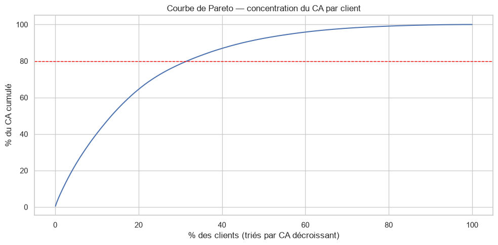

```python
# Analyse Pareto (80/20) : part du CA générée par le top X% des clients
ca_par_client = df.groupby("id_client")["chiffre_affaires"].sum().sort_values(ascending=False)
cum_pct_ca = ca_par_client.cumsum() / ca_par_client.sum()
cum_pct_clients = np.arange(1, len(ca_par_client) + 1) / len(ca_par_client)

pct_clients_pour_80pct_ca = (cum_pct_ca <= 0.8).sum() / len(ca_par_client)
print(f"{pct_clients_pour_80pct_ca:.1%} des clients génèrent 80% du chiffre d'affaires")

fig, ax = plt.subplots()
ax.plot(cum_pct_clients * 100, cum_pct_ca * 100)
ax.axhline(80, color="red", linestyle="--", linewidth=1)
ax.set_xlabel("% des clients (triés par CA décroissant)")
ax.set_ylabel("% du CA cumulé")
ax.set_title("Courbe de Pareto — concentration du CA par client")
plt.tight_layout()
plt.show()
```

```python
top10_clients = ca_par_client.head(10).to_frame("chiffre_affaires")
top10_clients
```

| id_client | chiffre_affaires |
| --- | --- |
| C0157 | 11,553.74 |
| C0266 | 10,673.23 |
| C0120 | 9,542.21 |
| C0003 | 9,516.10 |
| C0051 | 9,442.25 |
| C0379 | 9,105.69 |
| C0114 | 8,915.44 |
| C0067 | 8,476.41 |
| C0364 | 8,252.47 |
| C0054 | 8,080.54 |

```python
# Segmentation simple par valeur vie client (quartiles)
clv_par_client = df.drop_duplicates("id_client")[["id_client", "valeur_vie_client"]]
clv_par_client["segment"] = pd.qcut(
    clv_par_client["valeur_vie_client"], q=4, labels=["Occasionnel", "Standard", "Fidèle", "VIP"]
)
clv_par_client["segment"].value_counts().reindex(["Occasionnel", "Standard", "Fidèle", "VIP"])
```

```
segment
Occasionnel    437
Standard       437
Fidèle         436
VIP            437
Name: count, dtype: int64
```

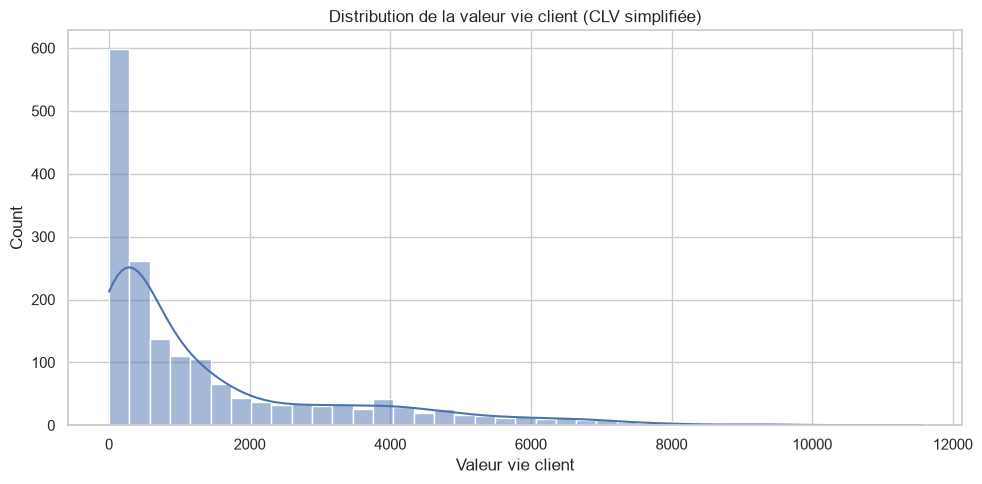

```python
fig, ax = plt.subplots()
sns.histplot(clv_par_client["valeur_vie_client"], bins=40, kde=True, ax=ax)
ax.set_title("Distribution de la valeur vie client (CLV simplifiée)")
ax.set_xlabel("Valeur vie client")
plt.tight_layout()
plt.show()
```

**Question stratégique — comment améliorer la rétention ?**

*(à conclure dans le résumé exécutif à partir du % de clients récurrents, de la concentration Pareto et de la rétention par canal ci-dessus.)*

## 5. Synthèse

Les résultats ci-dessus alimentent directement le **résumé exécutif**, les **5 recommandations stratégiques** et la **conclusion business** livrés séparément, ainsi que le **dashboard Streamlit** interactif pour l'exploration par la direction.